# 3rd wk REB meeting

Jonathan Harrison

25 October 2018

## Data driven production models

Wanted a data driven production model. Collected data on nascent transcription. Need to define: 1. distribution of production across cells 2. relative OE producton vs WT production

### Model M10

Take raw measurements of integrated fluorescence of nascent transcripts. Use these as estimates of production in each cell for each egg chamber, $\hat{a}_{ij}$.

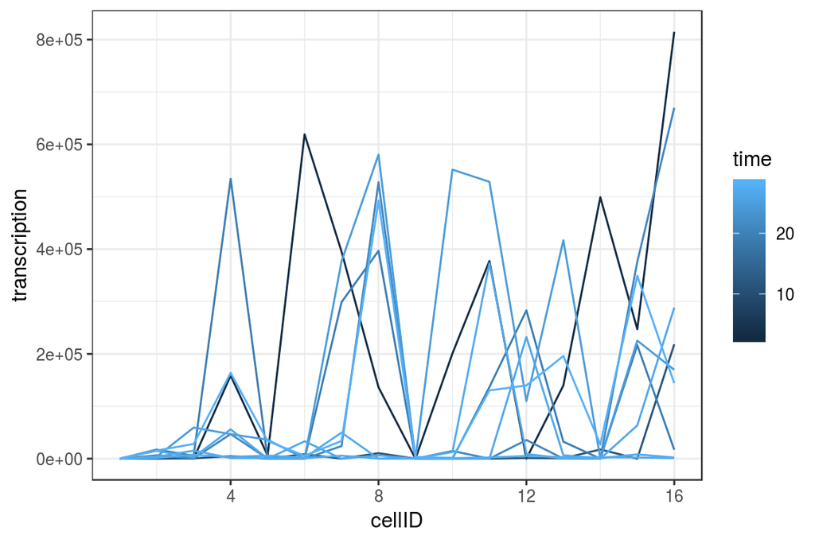

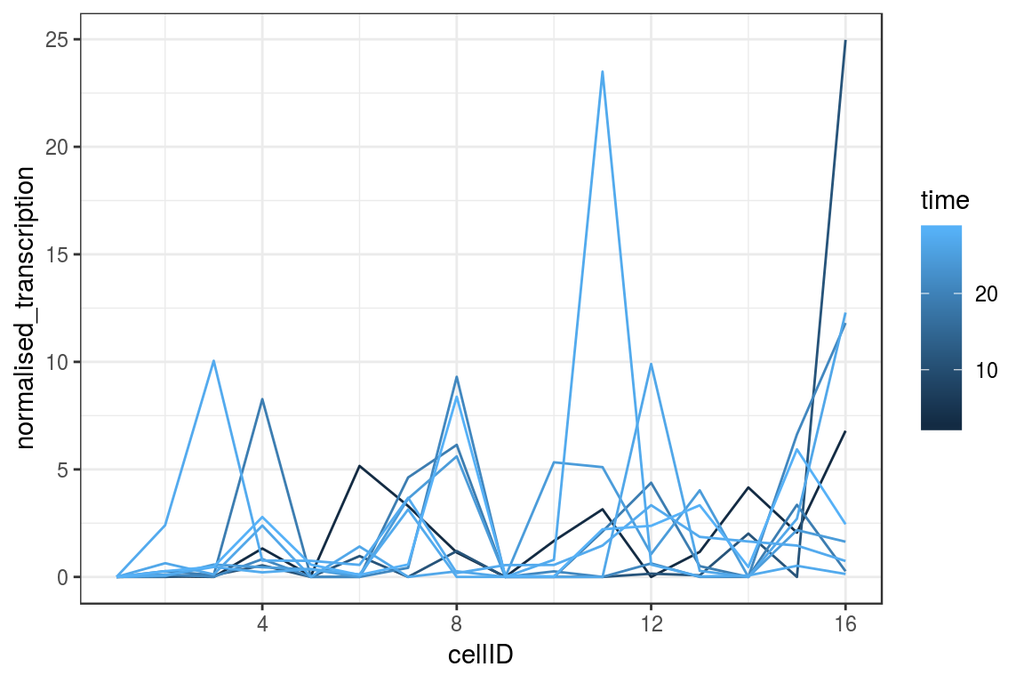

Problem with this: since the data come from fixed samples, the nascent transcripts only give us a single snapshot in time. The number of nascent transcripts gives an instantaneous snapshot of the transcription rate but for the model, production rate $a$, relates to a longer time scale average production. Instead we can attempt to model the fact that what we have observed is a random draw from a stochastic transcription process. In particular, the observed measurements contain quite a few zeros where no nascent transcripts above the cosen threshold were detected in a given cell.

## Model M11

Zero inflated poisson observation model for the transcription process.
$$p(y | \theta, \lambda) =
\begin{cases}
\theta + (1-\theta) \, \text{Poisson}(0|\lambda) \hspace{3mm} \text{if } y=0, \\
(1-\theta) \, \text{Poisson}(y|\lambda) \hspace{3mm} \text{if } y > 0
\end{cases}$$
We assume that there is some characteristic distribution of production across cells and all the egg chambers are noisy observations of this. This model could be fitted directly to the observations of nascent transcription to give estimates for the transcription in each cell, as follows.

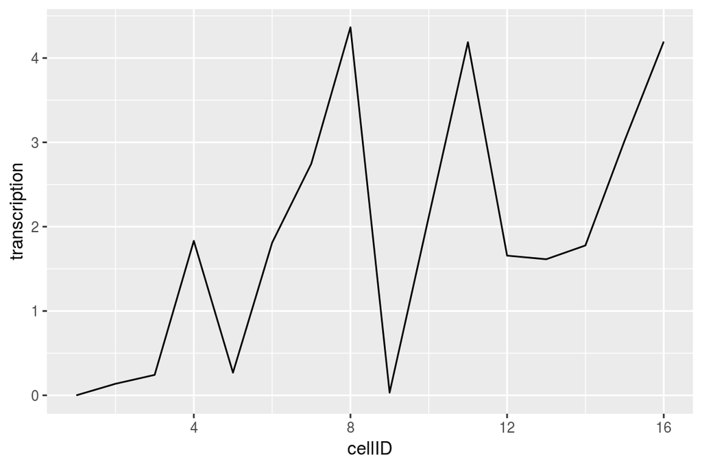

## Mode M12

Try also multiplying by 4 compared to WT production, rather than by 2.

## Compare production models

```
##
## loading fitted model parameters from model id: v431WT_simple
```

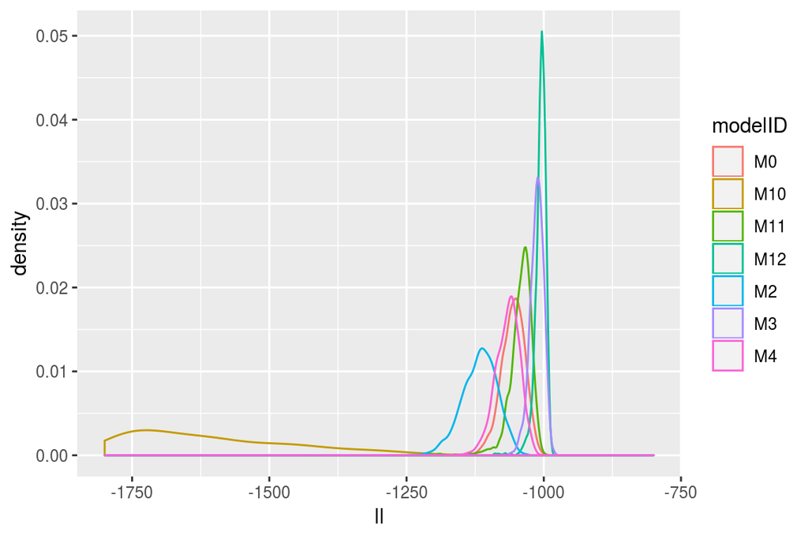

## Summary

It is hard to estimate inhomogeneous production rates from fixed biological data, even with direct observations since we only have a single time point for each biological sample.